# 03-assignment: Trees

Christopher Brown

October 12, 2015

## Readings

In Applied Predictive Modeling (APM) read: - Chapter 8.1 - 8.8, - Chapter 11 - Chapter 14.1 - 14.5, 14.8

## Problems: Due October 26th, 2015

- Project Update. (I will put a template in the projects folder for you to report your status on.)
- Exercises, In APM:

8.1 (a) - (C) 8.4 (a) - (b) 14.2

8.1

```r
library(mlbench)
set.seed(200)
simulated <- mlbench.friedman1(200, sd = 1)
simulated <- cbind(simulated$x, simulated$y)
simulated <- as.data.frame(simulated)
colnames(simulated)[ncol(simulated)] <- "y"
```

```r
library(randomForest)
library(caret)
model1 = randomForest(y ~ ., data = simulated, importance = TRUE, ntree = 1000)
rfImp1 = varImp(model1, scale = FALSE)

model1
```

```
##
## Call:
##  randomForest(formula = y ~ ., data = simulated, importance = TRUE,      ntree = 1000)
##                Type of random forest: regression
##                      Number of trees: 1000
## No. of variables tried at each split: 3
##
##           Mean of squared residuals: 6.562441
##                     % Var explained: 73.09
```

```r
rfImp1
```

```
##         Overall
## V1   8.98531278
## V2   6.41491561
## V3   0.72127525
## V4   7.84021295
## V5   2.10114942
## V6   0.16723018
## V7   0.08500129
## V8  -0.12728299
## V9  -0.07334252
## V10 -0.07688369
```

No significant usage of uninformative predictors (`V6` - `V10`).

```r
simulated$duplicate1 = simulated$V1 + rnorm(200) * .1
cor(simulated$duplicate1, simulated$V1)
```

```
## [1] 0.9394457
```

```r
model2 = randomForest(y ~ ., data = simulated, importance = TRUE, ntree = 1000)
rfImp2 = varImp(model2, scale = FALSE)

model2
```

```
##
## Call:
##  randomForest(formula = y ~ ., data = simulated, importance = TRUE,      ntree = 1000)
##                Type of random forest: regression
##                      Number of trees: 1000
## No. of variables tried at each split: 3
##
##           Mean of squared residuals: 7.021388
##                     % Var explained: 71.21
```

```r
rfImp2
```

```
##                Overall
## V1          6.15835308
## V2          6.21128515
## V3          0.71094923
## V4          6.89445061
## V5          2.12045732
## V6          0.21765826
## V7          0.01018861
## V8         -0.10213038
## V9         -0.09377993
## V10         0.07992643
## duplicate1  3.73887173
```

The importance score for `V1` decreases significantly when adding another predictor that is also highly correlated with `V1`.

```r
library(party)
set.seed(12345)
cforest1 = cforest(y ~ ., data = simulated[, 1:11], controls = cforest_control(ntree = 1000))
set.seed(12345)
cforest2 = cforest(y ~ ., data = simulated, controls = cforest_control(ntree = 1000))

cfImp1 = varimp(cforest1)
cfImp2 = varimp(cforest2)
# cfImp1con = varimp(cforest1, conditional = TRUE)
# cfImp2con = varimp(cforest2, conditional = TRUE)

cfImp1
```

```
##           V1           V2           V3           V4           V5
##  8.831947301  6.932990658  0.062255258  8.786136858  2.157644465
##           V6           V7           V8           V9          V10
## -0.024305911  0.074679243 -0.061906897  0.007462589 -0.010042157
```

```r
cfImp2
```

```
##           V1           V2           V3           V4           V5
##  6.419179934  6.503698103  0.039728988  8.132183239  2.012688657
##           V6           V7           V8           V9          V10
##  0.053796772  0.060650322 -0.030301052 -0.016801998 -0.008059005
##   duplicate1
##  3.094842815
```

```r
# cfImp1con
# cfImp2con
```

Yes, the pattern is almost the same. Also, conditional `varimp` is too slow to compute…

8.4

```r
library(AppliedPredictiveModeling)
data(solubility)
```

```r
# solTrain = solTrainXtrans[[209]]
# solTest = solTestXtrans[[209]]
solTrain = subset(solTrainXtrans, select="MolWeight")
solTest = subset(solTestXtrans, select="MolWeight")

set.seed(12345)
rpartmodel = train(solTrain, solTrainY, method = "rpart", tuneLength = 1)
rpartmodel
```

```
## CART
##
## 951 samples
##   1 predictor
##
## No pre-processing
## Resampling: Bootstrapped (25 reps)
## Summary of sample sizes: 951, 951, 951, 951, 951, 951, ...
## Resampling results
##
##   RMSE      Rsquared   RMSE SD    Rsquared SD
##   1.808896  0.3230368  0.1979633  0.02084419
##
## Tuning parameter 'cp' was held constant at a value of 0.3512348
##
```

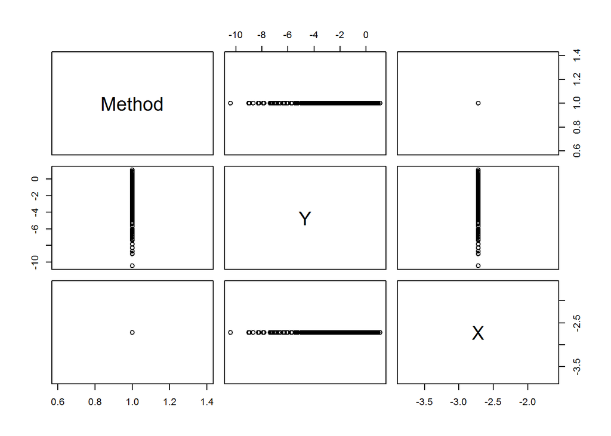

```r
rpartpred = predict(rpartmodel, solTest)
rpartTest = data.frame(Method = "rpart", Y=solTestY, X=rpartpred)
plot(rpartTest)
```

```r
set.seed(12345)
rfmodel = train(solTrain, solTrainY, method = "rf", tuneLength = 1)
rfmodel
```

```
## Random Forest
##
## 951 samples
##   1 predictor
##
## No pre-processing
## Resampling: Bootstrapped (25 reps)
## Summary of sample sizes: 951, 951, 951, 951, 951, 951, ...
## Resampling results
##
##   RMSE     Rsquared   RMSE SD    Rsquared SD
##   1.54366  0.4810384  0.0712058  0.03540577
##
## Tuning parameter 'mtry' was held constant at a value of 1
##
```

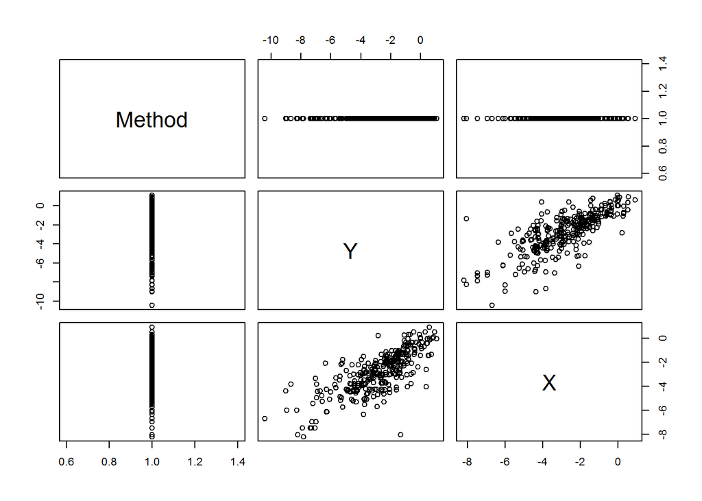

```r
rfpred = predict(rfmodel, solTest)
rfTest = data.frame(Method = "rf", Y=solTestY, X=rfpred)
plot(rfTest)
```

14.2

```r
library(C50)
data(churn)
```

```r
library(caret)
library(rpart)
library(rpart.plot)
set.seed(12345)
rpartmodel = train(churn ~., data = churnTrain, method = "rpart", tuneLength = 10)
rpartmodel
```

```
## CART
##
## 3333 samples
##   19 predictor
##    2 classes: 'yes', 'no'
##
## No pre-processing
## Resampling: Bootstrapped (25 reps)
## Summary of sample sizes: 3333, 3333, 3333, 3333, 3333, 3333, ...
## Resampling results across tuning parameters:
##
##   cp           Accuracy   Kappa      Accuracy SD  Kappa SD
##   0.003105590  0.9379823  0.7293825  0.007177321  0.03138386
##   0.004140787  0.9385692  0.7314925  0.007051785  0.03013690
##   0.007246377  0.9386608  0.7298212  0.007108941  0.03035721
##   0.012422360  0.9367084  0.7168555  0.007808823  0.03922593
##   0.017598344  0.9329298  0.6981412  0.006963499  0.03930646
##   0.018633540  0.9318234  0.6947034  0.006628663  0.03767851
##   0.052795031  0.9138776  0.5889536  0.016884758  0.11253575
##   0.078674948  0.8821424  0.3944693  0.014064350  0.14151261
##   0.084886128  0.8722324  0.2908617  0.014805259  0.17113798
##   0.089026915  0.8665366  0.2306481  0.014078427  0.16134849
##
## Accuracy was used to select the optimal model using  the largest value.
## The final value used for the model was cp = 0.007246377.
```

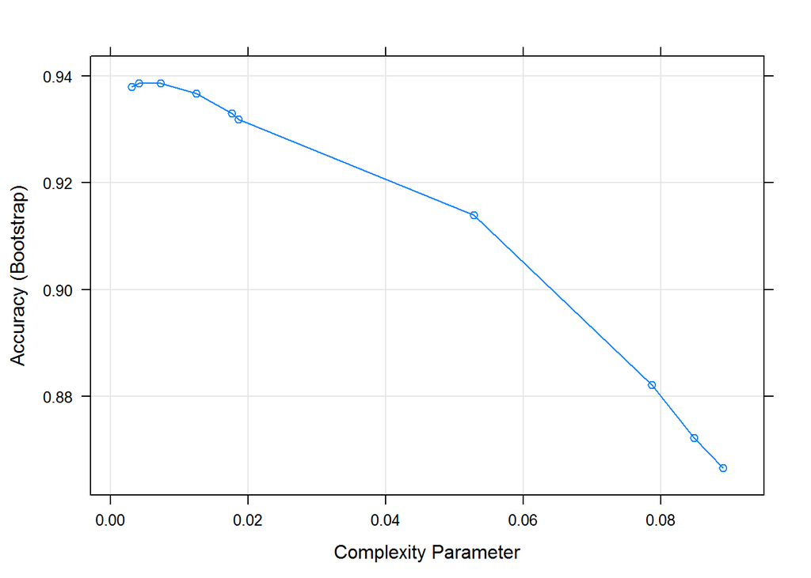

```r
plot(rpartmodel)
```

```r
rpartpred = predict(rpartmodel, churnTest)
rparttable = table(churnTest$churn, rpartpred)
(rparttable[[1]] + rparttable[[4]]) / nrow(churnTest)
```

```
## [1] 0.9436113
```

It is hard to interpret if using `cp` = 0.007246377. So we use some larger cp value (still with quite high accuracy).

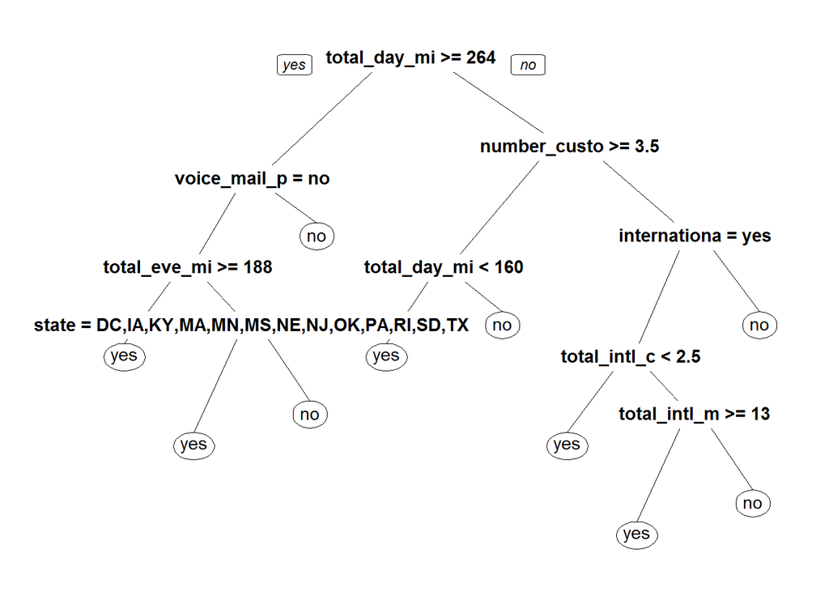

```r
rpartnew = rpart(churn ~., data = churnTrain, cp = 0.018)
prp(rpartnew)
```

It seems that `area_code` is a dummy variable since it doesn’t appear in the graph. If you decreases `cp`, it may appear but the model will become too complicated to interpret.

```r
library(ipred)
set.seed(12345)
rpart_bag = bagging(churn ~., data = churnTrain)
rpartpred_bag = predict(rpart_bag, churnTest)
rparttable_bag = table(churnTest$churn, rpartpred_bag)
(rparttable_bag[[2]] + rparttable_bag[[3]]) / nrow(churnTest)
```

```
## [1] 0.9454109
```

Improved slightly.

```r
library(adabag)
set.seed(12345)
rpart_boost = boosting(churn ~., data = churnTrain)
rpartpred_boost = predict(rpart_boost, churnTest)
rparttable_boost = table(churnTest$churn, rpartpred_boost$class)
(rparttable_boost[[2]] + rparttable_boost[[3]]) / nrow(churnTest)
```

```
## [1] 0.9478104
```

Improved slightly more.

```r
C50Model = C5.0(churn ~., data = churnTrain)
C50pred = predict(C50Model, churnTest)
C50table = table(churnTest$churn, C50pred)
(C50table[[1]] + C50table[[4]]) / nrow(churnTest)
```

```
## [1] 0.9472106
```

The performance is better than simple CART (`cp` tuned), and between bagging and boosting.

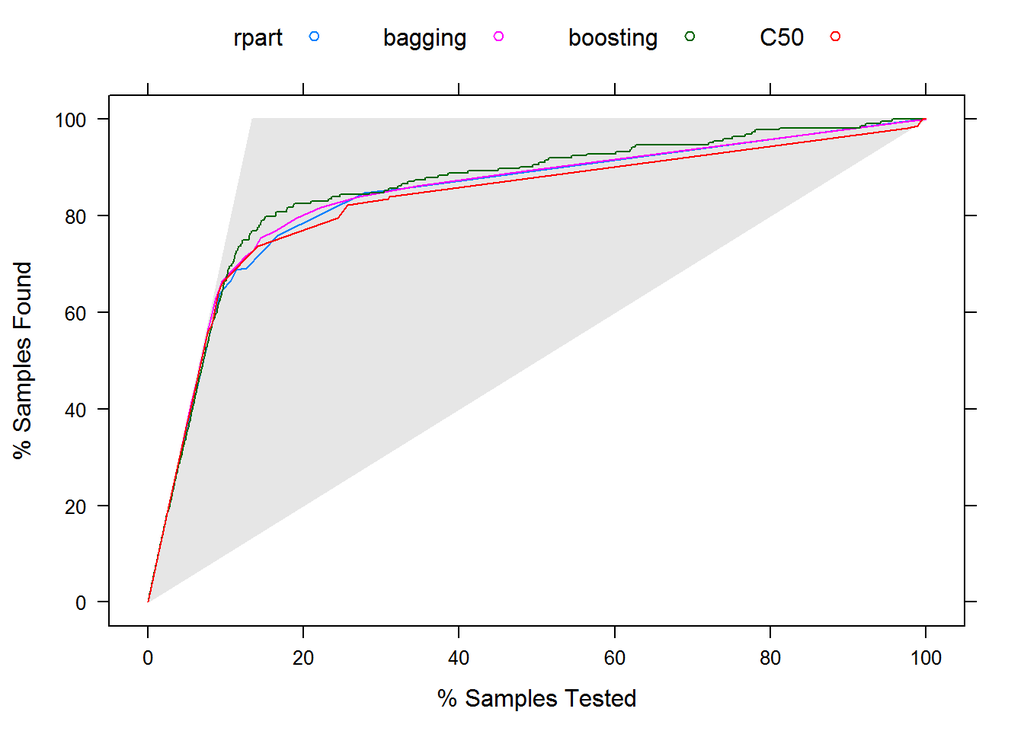

```r
# library(BCA)
# churn.rpart = rpartmodel
# churn.bagging = rpart_bag
# churn.boosting = rpart_boost
# churn.C50 = C50Model
#
# lift.chart(c("churn.rpart"), data=churnTest)

pred = data.frame(test = churnTest$churn,
                  rpart = (predict(rpartmodel, churnTest, type = "prob"))$yes,
                  bagging = (predict(rpart_bag, churnTest, type = "prob"))[,1],
                  boosting = rpartpred_boost$prob[,1],
                  C50 = (predict(C50Model, churnTest, type = "prob"))[,1])
lift = lift(test ~ rpart + bagging + boosting + C50, data = pred)
xyplot(lift, auto.key = list(columns = 4))
```